# Exercise: Reproducibility - Group 1

Michael Schulte-Mecklenbeck (Source: https://github.com/datacarpentry)

05 June, 2019

This RMarkdown file contains R code you can use to complete the exercise on reproducibility. To see the output simply click on *Knit to HTML* above. This might prompt you to install and load some required packages, specifically `knitr`.

## Packages:

We will use packages from **tidyverse**, a collection of R packages that share common philosophies and are designed to work together.

If you have not yet done so, install tidyverse via `install.packages(tidyverse)`.

Now we need to explicitly load the **tidyverse** packages:

```r
  library("tidyverse")
```

## Part 1: Analyze + document

#### 1. Load the data:

Note that `read_csv` uses `stringsAsFactors = FALSE` by default.

```r
  gap_5060 <- read_csv("../0_data/gapminder-5060.csv")
```

#### 2. Visualize life expectancy over time for Canada in the 1950s and 1960s using a line plot.

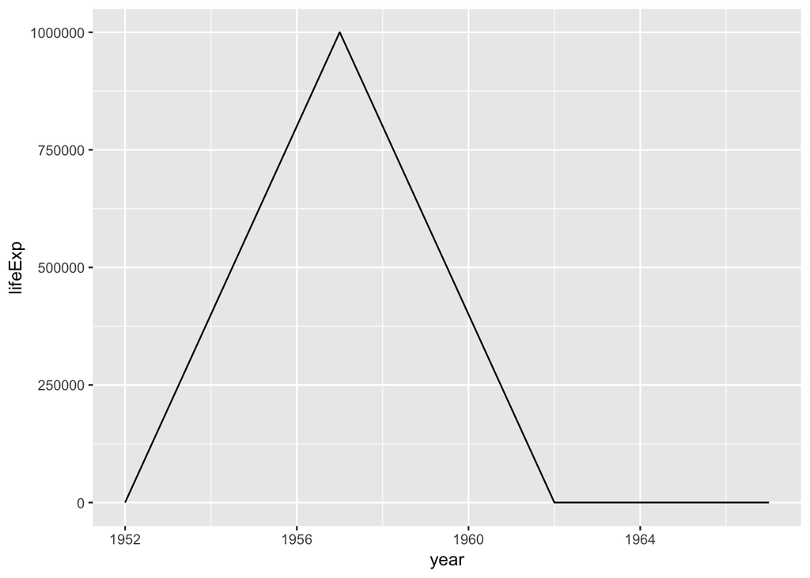

```r
# Filter the data for Canada only
  gap_5060_CA <-
    gap_5060 %>%
    filter(country == "Canada")
# Visualize
  ggplot(data = gap_5060_CA, aes(x = year, y = lifeExp)) +
    geom_line()
```

Something is clearly wrong with this plot! Some people live exceptionally long lives.

#### 3. Make appropriate corrections.

Turns out there’s a data error in the data file: life expectancy for Canada in the year 1957 is coded as `999999`, it should actually be `69.96`. We now make this correction:

```r
  gap_5060 <-
    gap_5060 %>%
    mutate(lifeExp = replace(lifeExp, (country == "Canada" & year == 1957), 69.96))
```

Hey - we changed the problematic value AND documented it in one go - awesome!

#### 4. Visualize life expectancy over time for Canada again, with the corrected data.

Exact same code as before, but note that the contents of `gap_5060` are different as it has been updated in the previous task.

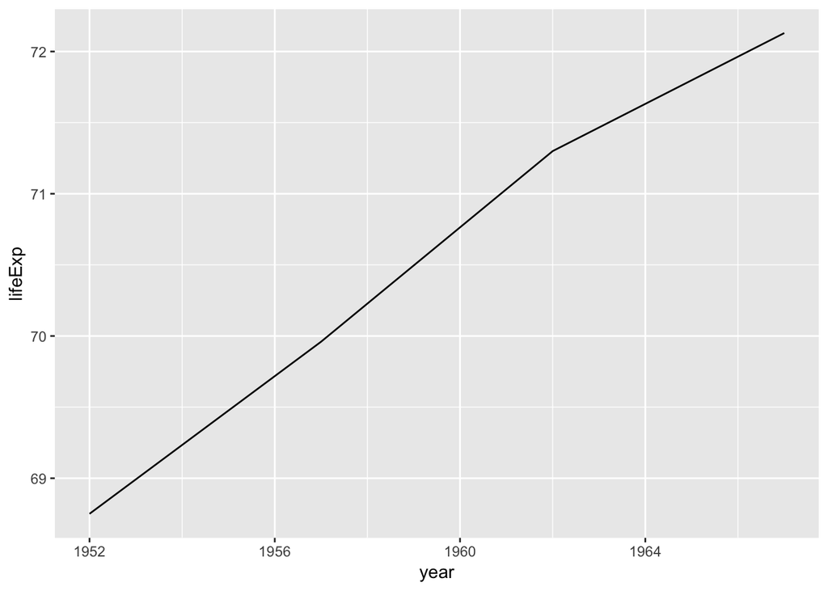

```r
  gap_5060_CA <-
    gap_5060 %>%
    filter(country == "Canada")

  ggplot(data = gap_5060_CA, aes(x = year, y = lifeExp)) +
    geom_line()
```

#### 4 - Stretch goal. Add lines for Mexico and United States.

- `%in%` for logical operator testing if a country’s name is in the list provided
- Same visualization code as before, only difference is the input dataset

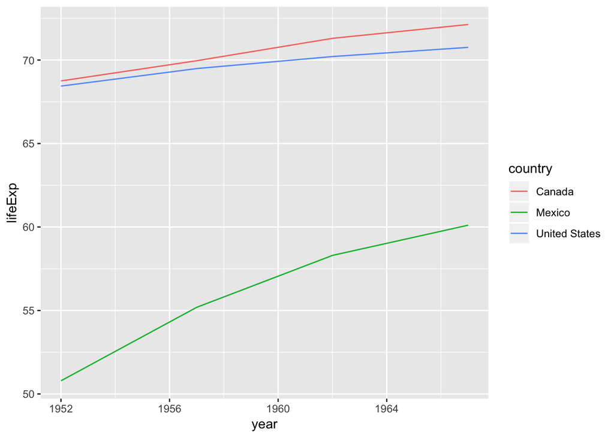

```r
  gap_5060_multiple <-
    gap_5060 %>%
    filter(country %in% c("Canada", "Mexico", "United States"))

  ggplot(data = gap_5060_multiple, aes(x = year, y = lifeExp, color = country)) +
    geom_line()
```